# Monte Carlo 추론 예제

(1) 3개의 각기 다른 표본에서의 추정치와 추정치의 분산을 비교할 것.

(2) 반복을 1000번하여 95% confidence interval을 제시할 것

(3) (1)번에 대응하여 MonteCarlo 추론(모수 예측과 confidence interval) 결과를 제시하고 그 결과를 (1)과 비교할 것.

## 0. 함수 정의 및 표본 생성

generate_logistic() 함수를

(1) -5.0부터 5.0까지 0.2 간격으로 생성한 50개의 x와

(2) (1)에서 생성한 x에 $a+bx+cx^2$(a=1, b=2, c=3) 을 취한 뒤 α=2, β=5인 베타분포를 따르는 랜덤한 값*18을 더하여 생성한 50개의 y를 리턴하는 함수로 정의하고, 세 번 실행하여 각각 sample1, sample2, sample3로 명명한다. sample1~3의 x, y에 비선형 최소제곱법으로 모델을 적합하는 curve_fit() 함수를 적용하고, 모델함수 인자로 y를 생성하는 데 사용한 2차 다항식 (1+2*x+3*x^2)을 넘긴다.

```python
# general libraries
import numpy as np
import matplotlib.pyplot as plt
from scipy.optimize import curve_fit
```

```python
def func_2(p, a, b, c):
  """
  Two-degree polynomial.2차함수(다항식)
  """
  return a + b*p + c*p**2
```

```python
# 숙제!
# size=0.2로 수정: 표본크기를 50으로 하기 위해

def generate_logistic(size=0.2):
    x = np.arange(-5.0, 5.0, size, dtype = np.float64)
    y = func_2(x, 1, 2, 3) + 18.0 * np.random.beta(2,5, size = len(x))
    print(len(x))
    return x,y
```

```python
x,y=generate_logistic()
x1,y1 = generate_logistic()
x2,y2 = generate_logistic()
```

```
50
50
50
```

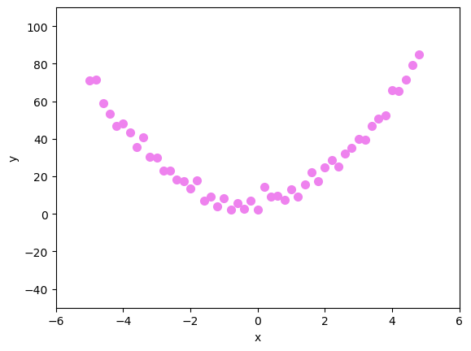

```python
fig = plt.figure()
ax = fig.add_subplot(111) # 1행 1열의 첫 번째라는 뜻. (1,1,1)로 작성해도 됨
# plt.figure.add_subplot()은 axes.Axes 객체를 반환한다.
# Axes는 플롯의 이미지, 축의 메모리, 레이블 설정 등을 담당한다.

ax.scatter(x, y, color = 'violet', linewidths = 2)

plt.ylabel('y')
plt.xlabel('x')

plt.ylim(-50, 110)
plt.xlim(-6, 6)

plt.axis(True)
plt.show()
```

#### curve_fit(모델함수, x, y)

- 모델함수: 데이터를 추정하기 위한 함수의 기본형
- return: popt, pcov
  - popt: 모델함수의 파라미터
  - pcov: popt의 공분산 추정값 (대각성분은 Cov(X,X) 즉 Var(X) 이다)

```python
# 선형모형 추정
popt, pcov = curve_fit(func_2, x, y)
popt1, pcov1 = curve_fit(func_2, x1, y1)
popt2, pcov2 = curve_fit(func_2, x2, y2)
# 추정하는 파라미터의 적정 범위를 알고 있다면 curve_fit()의 인자로 bounds=([a최소값, b최소값], [a최대값, b최대값])을 입력하여
# 파라미터의 자유도를 제한함으로써 원하는 함수를 더 정확히 추정할 수 있다. 하지만 범위 설정이 잘못되면 원하는 결과를 얻지 못할 것임
```

## 1. 세 개의 각기 다른 표본에서 추정치와 추정치의 분산을 비교하기

### 1) a, b, c 추정치

curve_fit() 함수가 반환하는 popt는 잔차제곱합이 최소가 되는 최적의 모수 즉 a, b, c의 추정치를 알려주며 sample1~3에 대하여 다음과 같다(리스트의 왼쪽부터 a, b, c 순서).

```python
print('sample1:', popt) # 실행할 때마다 바뀐다
print('sample2:', popt1)
print('sample3:', popt2)
```

```
sample1: [6.24388813 1.87648732 2.99438957]
sample2: [6.41926863 2.20131134 2.97918476]
sample3: [6.20433111 2.03120348 3.01950174]
```

### 2) a, b, c 추정치의 분산

pcov의 대각성분은 각 파라미터의 variance이다. curve_fit() 함수가 반환하는 pcov의 대각성분으로부터 얻을 수 있는 a, b, c 추정치의 분산은 다음과 같다(리스트의 왼쪽부터 a, b, c 순서).

- 파라미터의 uncertainties를 pcov로부터 확인하기
  - 행렬 대각화: np.diag(pcov)

```python
print(pcov)

# 실행할 때마다 아래 값이 변경됨을 확인
# 수리통계학의 통계적 추론이 복불복이라는 것.
```

```
[[ 0.40799964 -0.00326574 -0.02721449]
 [-0.00326574  0.02190243  0.00065419]
 [-0.02721449  0.00065419  0.00327097]]
```

```python
perr = np.diag(pcov)
perr1 = np.diag(pcov1)
perr2 = np.diag(pcov2)
print("sample1:", perr)
print("sample2:", perr1)
print("sample3:", perr2)
# curve_fit()의 bounds 인자의 값을 변경할 때 perr값을 참고하며 perr이 작아지도록 bounds를 조정한다
```

```
sample1: [0.40799964 0.02190243 0.00327097]
sample2: [0.4741755  0.02545492 0.00380151]
sample3: [0.40791261 0.02189776 0.00327027]
```

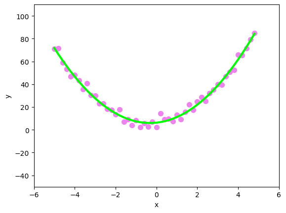

```python
fig = plt.figure()
ax = fig.add_subplot(111)

ax.scatter(x, y, color = 'violet', linewidths = 2)
ax.plot(x, func_2(x, *popt), lw = 3, color = 'lime')

plt.ylabel('y')
plt.xlabel('x')

plt.ylim(-50, 110)
plt.xlim(-6, 6)

plt.axis(True)
plt.show()
```

## 2. 1000회 반복하여 95% CI 구하기

```python
import pandas as pd

# 기본값: 100회 추출
def dist_est(x,repeat=100, sigma=18.0):
    y_2 = []
    popt_l = []
    for i in range (0, repeat):
        # 재현을 위해 seed 설정
        np.random.seed(seed = i)
        # beta분포로 변경
        y_2.append(func_2(x, 1, 2, 3) + sigma * np.random.beta(2, 5, size = len(x)))
        popt, _ = curve_fit(func_2, x, y_2[i])
        popt_l.append(popt)
    est_params=pd.DataFrame(popt_l, columns=['a','b','c'])
    print(f'repeat={repeat}',f'sigma={sigma}')
    print(est_params.describe())
    print('====================95% confidence interval=====================')
    print(est_params.quantile(q=0.025))
    print(est_params.quantile(q=0.975))
```

### repeat = 1000, sigma = 18.0

1.번과 동일한 분포에서 Sample size가 50인 표본을 추출하는 과정을 1000회 반복한다. 총 1000개의 표본에 각각 2차 다항식 모델함수를 적합하여 모수 a, b, c의 추정치의 95%가 포함된 구간을 구하면 다음과 같다.

```python
dist_est(x,repeat=1000) # a의 표준편차 = 0.584632
```

```
repeat=1000 sigma=18.0
                 a            b            c
count  1000.000000  1000.000000  1000.000000
mean      6.131763     2.008358     3.000804
std       0.584632     0.144138     0.054408
min       4.346979     1.480477     2.805282
25%       5.737318     1.911272     2.964398
50%       6.145950     2.004442     3.001115
75%       6.514532     2.104732     3.034041
max       8.120159     2.555677     3.187466
====================95% confidence interval=====================
a    5.015707
b    1.728524
c    2.899601
Name: 0.025, dtype: float64
a    7.245094
b    2.295969
c    3.110235
Name: 0.975, dtype: float64
```

```python
print(0.584632**2)
print(0.144138**2)
print(0.054408**2)
```

```
0.34179457542400005
0.020775763043999997
0.0029602304639999998
```

## 3. (1)번에 대응하여 MonteCarlo 추론(모수 예측과 confidence interval) 결과를 제시하고 그 결과를 (1)과 비교할 것.

```python
# 상단에서 사용한 x y 페어를 다시 사용한다

xx = pd.DataFrame(x,columns=['x'])
yyy = pd.DataFrame(y,columns=['y'])
data = pd.merge(xx,yyy,left_index=True,right_index=True)

xx1 = pd.DataFrame(x1,columns=['x'])
yyy1 = pd.DataFrame(y1,columns=['y'])
data1 = pd.merge(xx1,yyy1,left_index=True,right_index=True)

xx2 = pd.DataFrame(x2,columns=['x'])
yyy2 = pd.DataFrame(y2,columns=['y'])
data2 = pd.merge(xx2,yyy2,left_index=True,right_index=True)

print(data.shape)
print(data1.shape)
print(data2.shape)
```

```
(50, 2)
(50, 2)
(50, 2)
```

```python
def resample_est(n_iter=1000, frac=1, data=data):
    pop_sample=[]
    for _ in range(n_iter):
        resample=data.sample(frac=frac,replace=True)
        # frac: 전체 표본수 대비 추출 비율
        popt, _ = curve_fit(func_2, resample['x'], resample['y'])
        pop_sample.append(popt)
    est_params=pd.DataFrame(pop_sample, columns=['a','b','c'])
    print(f'n_iter={n_iter}',f'sample size={len(data)}',f'fraction={frac}')
    print(est_params.describe())
    print('==========95% confidence interval===========') # a, b, c의 95% 신뢰구간
    print(est_params.quantile(q=0.025))
    print(est_params.quantile(q=0.975))
```

### 3.1 data(50,2)에서 추출, 1000회 반복, 표본 크기는 50

```python
resample_est(data=data)
```

```
n_iter=1000 sample size=50 fraction=1
                 a            b            c
count  1000.000000  1000.000000  1000.000000
mean      6.268230     1.880330     2.991225
std       0.694785     0.136398     0.058920
min       4.050532     1.335228     2.810251
25%       5.780437     1.790273     2.952141
50%       6.242837     1.877663     2.989964
75%       6.750753     1.977678     3.031435
max       8.779713     2.424223     3.203100
==========95% confidence interval===========
a    4.914687
b    1.603313
c    2.881390
Name: 0.025, dtype: float64
a    7.658831
b    2.132690
c    3.102350
Name: 0.975, dtype: float64
```

### 3.2 data1에서 추출, 1000회 반복, 표본 크기는 50

```python
resample_est(data = data1)
```

```
n_iter=1000 sample size=50 fraction=1
                 a            b            c
count  1000.000000  1000.000000  1000.000000
mean      6.443842     2.198570     2.978648
std       0.672906     0.162834     0.060179
min       4.082772     1.567063     2.774335
25%       5.986616     2.096768     2.938635
50%       6.451691     2.206012     2.980133
75%       6.915689     2.302971     3.020025
max       8.264019     2.723859     3.224712
==========95% confidence interval===========
a    5.185149
b    1.866934
c    2.865507
Name: 0.025, dtype: float64
a    7.758013
b    2.512951
c    3.091355
Name: 0.975, dtype: float64
```

### 3.2 data2에서 추출, 1000회 반복, 표본 크기는 50

```python
resample_est(data = data2)
```

```
n_iter=1000 sample size=50 fraction=1
                 a            b            c
count  1000.000000  1000.000000  1000.000000
mean      6.203802     2.025950     3.017375
std       0.677933     0.146565     0.060997
min       4.227025     1.560430     2.796045
25%       5.753975     1.931945     2.978212
50%       6.198617     2.027804     3.020606
75%       6.638395     2.120841     3.057746
max       8.291952     2.463534     3.217477
==========95% confidence interval===========
a    4.864582
b    1.740974
c    2.894856
Name: 0.025, dtype: float64
a    7.559762
b    2.315390
c    3.136862
Name: 0.975, dtype: float64
```